# Sample Construction

Author

Gustave Kenedi and Louis Sirugue

Published

April 11, 2023

## Packages

```r
packages <- c("here","tidyverse", "data.table", "furrr", "readxl", "janitor", "ggthemr", "furrr", "broom", "tidylog")
librarian::shelf(packages, quiet = TRUE)
rm(packages)
```

## Functions

```r
source(here("code_lib/useful_functions.R"))
```

## Params

```r
# figures
fig_height = 6
fig_width = (16/9)*fig_height
ggthemr("pale")

theme_update(text = element_text(size = 14),
             legend.title = element_text(face = "italic", size = 12),
             legend.text = element_text(size = 12),
             legend.background = element_rect(fill = alpha("white", .75)),
             plot.caption = element_text(size = 8, face = "italic", color = "#7d7d7d"))

# no scientific notation
options(scipen=999)

# path to data
data_path <- "~/Dropbox/3resources/data/psid/"
```

## Load data

```r
# PSID variables dictionary
psid_vars <- read_excel(paste0(data_path, "fims/psid.xlsx")) %>%
  clean_names() %>%
  mutate(var_id = 1:n()) %>%
  pivot_longer(cols = -c(var_id, type, category, text, head_wife, var_count),
               names_prefix = "y",
               names_to = "year",
               values_to = "variable")

# individual file
ind_2019 <- fread(paste0(data_path, "ind2019er/IND2019ER.csv"))
ind_2019 <- ind_2019 %>%
  mutate(fam_id_68 = ER30001,
         person_num_68 = ER30002,
         ind_id_68 = fam_id_68*1000 + person_num_68,
         gender = case_when(ER32000 == 1 ~ "Male",
                            ER32000 == 2 ~ "Female"))
setDT(ind_2019)
# fam_id_68 and person_num_68 uniquely identify every individual in the sample
# my ind_id_68 variable uniquely identifies individuals
ind_2019[, .N, by = list(fam_id_68, person_num_68)] %>% count(N)
ind_2019[, .N, by = ind_id_68] %>% count(N)

# income dataset created by income_data.qmd
inc_all <- fread(here("data/inc_all.csv"))

# family files 1968-20219
years <- c(1968:1997, seq(1999, 2019, 2))
for (i in years) {
  print(i)

  if (i %in% 1968:1993) {
    file_path <- paste0(data_path, "fam", i, "/FAM", i)
  } else {
    file_path <- paste0(data_path, "fam", i, "er", "/FAM", i, "ER")
  }

  assign(paste0("fam_", i), fread(paste0(file_path, ".csv")))
}

gc()
```

## Family id + relation to head variables

```r
# initiate variable used data.frame ----
used_vars <- as_tibble(years)
# -----

# family interview id ----
psid_vars %>% filter(var_id == 8746) %>% count(text)
fam_id_vars <- psid_vars %>% filter(var_id == 8746) %>% pull(variable)
used_vars <- bind_cols(used_vars, fam_id_vars = fam_id_vars)
# ----

# relation to head ----
psid_vars %>% filter(var_id == 422) %>% count(text)
rel_head_vars <- psid_vars %>% filter(var_id == 422) %>% pull(variable)
used_vars <- bind_cols(used_vars, rel_head_vars = rel_head_vars)
# ----
```

## Interview number, person number, sample/nonsample definitions

```r
ind_2019 <- ind_2019 %>%
  mutate(itw_num_cat = case_when(ER30001 %in% 1:2930 ~ "Member of, or moved into, a family from the 1968 SRC cross-section sample",
                                 ER30001 %in% 3001:3441 ~ "Member of, or moved into, a family from the Immigrant sample added in 1997",
                                 ER30001 %in% 3442:3511 ~ "Member of, or moved into, a family from the Immigrant sample added in 1999",
                                 ER30001 %in% 4001:4462 & ER32052 == 2017 ~ "Member of, or moved into, a family from the Immigrant sample added in 2017",
                                 ER30001 %in% 4001:4462 & ER32052 == 2019 ~ "Multiplicity sample not interviewed until 2019",
                                 ER30001 %in% 4700:4851 ~ "Member of, or moved into, a family from the Immigrant sample added in 2019",
                                 ER30001 %in% 5001:6872 ~ "Member of, or moved into, a family from the 1968 Census sample",
                                 ER30001 %in% 7001:9043 ~ "Member of, or moved into, a family from the Latino sample added in 1990",
                                 ER30001 %in% 9044:9308 ~ "Member of, or moved into, a family from the Latino sample added in 1992"),
         person_num_cat = case_when(ER30002 %in% 1:19 ~ "1. Individuals living in core sample families at the time of the 1968 interview; individuals living in Latino sample families at the time of the 1990 (or 1992) interview; individuals living in Immigrant sample families at the time of the 1997 (or 1999) or 2017 (or 2019) interview",
                                    ER30002 %in% 20 ~ "Husband of a core sample 1968 Head living in an institution at the time of the 1968 interview; spouse of a Latino sample 1990 Head living in an institution at the time of the 1990 interview; spouse of an Immigrant sample 1997/1999 or 2017/2019 Head/Reference Person living in an institution at the time of the 1997/1999 or 2017/2019 interview",
                                    ER30002 %in% 21:26 ~ "2. Children or stepchildren of a 1968 core sample Head who were under 25 and living in institutions at the time of the 1968 interview; children of a Latino sample 1990 (or 1992) Head who were under 25 and living in institutions at the time of the 1990 (or 1992) interview; children of an Immigrant sample 1997 (or 1999) or 2017 (or 2019) Head/Reference Person who were under 25 and living in institutions at the time of the 1997 (or 1999) or 2017 (or 2019) interview",
                                    ER30002 %in% 30:169 ~ "3. Individuals born into the core sample since the 1968 interview, the Latino sample since the 1990 (or 1992) interview, or the Immigrant sample since the 1997 (or 1999) or 2017 (or 2019) interview and who have at least one sample parent; these persons are sample members",
                                    ER30002 %in% 170:226 ~ "4. Individuals who moved into a core family for the first time after the 1968 interview or who have no sample parent; individuals from the Latino sample, other than the spouse of a 1990 (or 1992) Head, who moved out in the year preceding the 1990 (or 1992) interview or who moved in for the first time after the 1990 (or 1992) interview; individuals from the 97 Immigrant sample, other than the spouse of a 1997 (or 1999), who moved out in the year preceding the 1997 (or 1999) interview or who moved in for the first time after the 1997 (or 1999) interview; individuals from the 17 Immigrant sample, other than the spouse of a 2017 (or 2019) Head/Reference Person, who moved out in the year preceding the 2017 (or 2019) interview or who moved in for the first time after the 2017 (or 2019) interview.\nThese individuals are nonsample unless they were born after the initial wave and have at least one sample parent.",
                                    ER30002 %in% 227 ~ "5. Spouse of a core sample 1968 Head who moved out in the year prior to the 1968 interview; spouse of a Latino sample 1990 Head who moved out in the year preceding the 1990 (or 1992) interview; spouse of an Immigrant sample 1997 (or 1999) Head who moved out in the year preceding the 1997 (or 1999) interview. Spouse of an Immigrant sample 2017 (or 2019) Reference Person who moved out in the year preceding the 2017 (or 2019) interview.\nThese individuals are nonsample.",
                                    ER30002 %in% 228 ~ "6. Spouse of a core sample 1968 Head who died in the year prior to the 1968 interview; spouse of a Latino sample 1990 (or 1992) Head who died in the year prior to the 1990 (or 1992) interview; spouse of an Immigrant sample 1997 (or 1999) Head who died in the year prior to the 1997 (or 1999) interview; spouse of an Immigrant sample 2017 (or 2019) Reference Person who died in the year prior to the 2017 (or 2019) interview.\nThese individuals are nonsample.",
                                    ER30002 %in% 229:399 ~ "7. Individuals who moved into a core family for the first time after the 1968 interview or who have no sample parent; individuals from the Latino sample, other than the spouse of a 1990 (or 1992) Head, who moved out in the year preceding the 1990 (or 1992) interview or who moved in for the first time after the 1990 (or 1992) interview; individuals from the 97 Immigrant sample, other than the spouse of a 1997 (or 1999) Head, who moved out in the year preceding the 1997 (or 1999) interview or who moved in for the first time after the 1997 (or 1999) interview; individuals from the 17 Immigrant sample, other than the spouse of a 2017 (or 2019) Reference Person, who moved out in the year preceding the 2017 (or 2019) interview or who moved in for the first time after the 2017 (or 2019) interview.\nThese individuals are nonsample unless they were born after the initial wave and have at least one sample parent. This series is simply a continuation of the 170-226 group."),
         sample_status = case_when(ER32006 == 0 ~ "This individual is nonsample and not part of the elderly group",
                                   ER32006 == 1 ~ "This individual is original sample",
                                   ER32006 == 2 ~ "This individual is born-in sample",
                                   ER32006 == 3 ~ "This individual is moved-in sample",
                                   ER32006 == 4 ~ "This individual is joint inclusion sample",
                                   ER32006 == 5 ~ "This individual was a followable nonsample parent",
                                   ER32006 == 6 ~ "This individual is nonsample elderly"))

ind_2019 %>% count(itw_num_cat, sort = T) %>% count_to_pct()
ind_2019 %>% count(person_num_cat, sort = T) %>% count_to_pct()
ind_2019 %>% count(sample_status, sort = T) %>% count_to_pct()
```

## Child sample

Only keep individuals:

1. born between 1963 (56 in 2019, income measured at 55) and 1988 (31 in 2019, income measured at 30)
2. observed as child (i.e., with parents) at least once
3. observed at least once as head or spouse between 30 and 50 (i.e., we can observed their taxable family income)

Following Chetty et al. (2014 QJE), for each child, we define parent(s) as the “reference person” and “spouse/partner” of the family unit in which the child is first observed. In the PSID, the child is often first observed at birth.

Note that we don’t restrict to children whose parent(s) has at least one family income observation because depending on the parent income variable the number of observations could vary.

### Restriction (i): born between 1963-1988

Since prior to 1983, only age (rather than birth year) was reported, we use the following rule to obtain individuals’ birth year:

1. if at least 1 birth year value: most common value;
2. otherwise: most common value obtained from year - age (by definition this will equal birth year or birth year + 1).

```r
birth_year_min = 1963
birth_year_max = 1988

# obtain birth year of individuals
# note: before 1983, only age was asked
psid_vars %>% filter(var_id == 17) %>% count(text)
```

| text | n |
| --- | --- |
| 01>DEMOGRAPHIC:\r\n02>Age: | 41 |

```r
age_vars <- psid_vars %>% filter(var_id == 17 & year < 1983) %>% pull(variable)
age_vars
```

```
 [1] "ER30004" "ER30023" "ER30046" "ER30070" "ER30094" "ER30120" "ER30141"
 [8] "ER30163" "ER30191" "ER30220" "ER30249" "ER30286" "ER30316" "ER30346"
[15] "ER30376"
```

```r
used_vars <- bind_cols(used_vars, age_vars = c(age_vars, rep(NA, length(years) - length(age_vars))))

psid_vars %>% filter(var_id == 15) %>% count(text)
```

| text | n |
| --- | --- |
| 01>DEMOGRAPHIC:\r\n02>Age:\r\n03>from birthdate:\r\n04>year born: | 41 |

```r
birth_year_vars <- psid_vars %>% filter(var_id == 15 & year %in% 1983:2019) %>% pull(variable)
birth_year_vars
```

```
 [1] "ER30404" "ER30434" "ER30468" "ER30503" "ER30540" "ER30575" "ER30611"
 [8] "ER30647" "ER30694" "ER30738" "ER30811" "ER33106" "ER33206" "ER33306"
[15] "ER33406" "ER33506" "ER33606" "ER33706" "ER33806" "ER33906" "ER34006"
[22] "ER34106" "ER34206" "ER34307" "ER34506" "ER34706"
```

```r
used_vars <- bind_cols(used_vars, birth_year_vars = c(rep(NA, length(age_vars)), birth_year_vars))


# replace "999" or "9999" values by missing
sapply(ind_2019 %>% select(all_of(c(age_vars, birth_year_vars))), function(x) max(x, na.rm = T))
```

```
ER30004 ER30023 ER30046 ER30070 ER30094 ER30120 ER30141 ER30163 ER30191 ER30220
    999     999     999     999     999     999     999     999     999      98
ER30249 ER30286 ER30316 ER30346 ER30376 ER30404 ER30434 ER30468 ER30503 ER30540
    999     999     999     999     999    9999    9999    9999    9999    9999
ER30575 ER30611 ER30647 ER30694 ER30738 ER30811 ER33106 ER33206 ER33306 ER33406
   9999    9999    9999    9999    9999    9999    9999    9999    9999    9999
ER33506 ER33606 ER33706 ER33806 ER33906 ER34006 ER34106 ER34206 ER34307 ER34506
   9999    9999    9999    9999    9999    9999    9999    9999    9999    9999
ER34706
   9999
```

```r
sapply(ind_2019 %>% select(all_of(c(age_vars, birth_year_vars))), function(x) sum(x %in% c(999, 9999)))
```

```
ER30004 ER30023 ER30046 ER30070 ER30094 ER30120 ER30141 ER30163 ER30191 ER30220
     24       7       2       1       3       3       6       6       3       0
ER30249 ER30286 ER30316 ER30346 ER30376 ER30404 ER30434 ER30468 ER30503 ER30540
      6       2       2       4       2     385     174     140     172     212
ER30575 ER30611 ER30647 ER30694 ER30738 ER30811 ER33106 ER33206 ER33306 ER33406
    238     182     268     316     303     445     346     119      77      60
ER33506 ER33606 ER33706 ER33806 ER33906 ER34006 ER34106 ER34206 ER34307 ER34506
     46      25      38      59      61      57      50      69      76     129
ER34706
    183
```

```r
ind_2019_clean <- ind_2019 %>%
  mutate(across(all_of(c(age_vars, birth_year_vars)), ~ ifelse(.x %in% c(999, 9999), NA, .x)))
sapply(ind_2019_clean %>% select(all_of(c(age_vars, birth_year_vars))), function(x) max(x, na.rm = T))
```

```
ER30004 ER30023 ER30046 ER30070 ER30094 ER30120 ER30141 ER30163 ER30191 ER30220
     98      98      97      98      98      98      98      98      98      98
ER30249 ER30286 ER30316 ER30346 ER30376 ER30404 ER30434 ER30468 ER30503 ER30540
     98      98      98      98      97    1983    1984    1985    1986    1987
ER30575 ER30611 ER30647 ER30694 ER30738 ER30811 ER33106 ER33206 ER33306 ER33406
   1988    1989    1990    1991    1992    1993    1994    1995    1996    1997
ER33506 ER33606 ER33706 ER33806 ER33906 ER34006 ER34106 ER34206 ER34307 ER34506
   1999    2001    2003    2005    2007    2009    2011    2013    2015    2017
ER34706
   2019
```

```r
sapply(ind_2019_clean %>% select(all_of(c(age_vars, birth_year_vars))), function(x) sum(x %in% c(999, 9999)))
```

```
ER30004 ER30023 ER30046 ER30070 ER30094 ER30120 ER30141 ER30163 ER30191 ER30220
      0       0       0       0       0       0       0       0       0       0
ER30249 ER30286 ER30316 ER30346 ER30376 ER30404 ER30434 ER30468 ER30503 ER30540
      0       0       0       0       0       0       0       0       0       0
ER30575 ER30611 ER30647 ER30694 ER30738 ER30811 ER33106 ER33206 ER33306 ER33406
      0       0       0       0       0       0       0       0       0       0
ER33506 ER33606 ER33706 ER33806 ER33906 ER34006 ER34106 ER34206 ER34307 ER34506
      0       0       0       0       0       0       0       0       0       0
ER34706
      0
```

```r
# create birth_year_[YEAR] variables
ind_2019_birth_dates <- bind_cols(ind_2019_clean %>% select(ind_id_68),
                                  1:length(years[years < 1983]) %>% map_dfc(~ ind_2019_clean %>%
                                                                              select(all_of(age_vars)) %>%
                                                                              mutate(!!paste0("birth_year_", years[.x]) := ifelse(.[[age_vars[.x]]] == 0, NA, years[.x] - .[[age_vars[.x]]])) %>%
                                                                              select(starts_with("birth_year_"))),
                                  1:length(c(1983:1997, seq(1999, 2019, 2))) %>% map_dfc(~ ind_2019_clean %>%
                                                                                           select(all_of(birth_year_vars)) %>%
                                                                                           mutate(!!paste0("birth_year_", years[length(years[years < 1983])+.x]) := ifelse(.[[birth_year_vars[.x]]] == 0, NA, .[[birth_year_vars[.x]]])) %>%
                                                                                           select(starts_with("birth_year_"))))
ind_2019_birth_dates %>% head
```

| ind_id_68 | birth_year_1968 | birth_year_1969 | birth_year_1970 | birth_year_1971 | birth_year_1972 | birth_year_1973 | birth_year_1974 | birth_year_1975 | birth_year_1976 | birth_year_1977 | birth_year_1978 | birth_year_1979 | birth_year_1980 | birth_year_1981 | birth_year_1982 | birth_year_1983 | birth_year_1984 | birth_year_1985 | birth_year_1986 | birth_year_1987 | birth_year_1988 | birth_year_1989 | birth_year_1990 | birth_year_1991 | birth_year_1992 | birth_year_1993 | birth_year_1994 | birth_year_1995 | birth_year_1996 | … |
| --- | --- | --- | --- | --- | --- | --- | --- | --- | --- | --- | --- | --- | --- | --- | --- | --- | --- | --- | --- | --- | --- | --- | --- | --- | --- | --- | --- | --- | --- | --- |
| 1001 | 1916 | 1915 | 1916 | NA | NA | NA | NA | NA | NA | NA | NA | NA | NA | NA | NA | NA | NA | NA | NA | NA | NA | NA | NA | NA | NA | NA | NA | NA | NA | … |
| 1002 | 1922 | 1921 | 1922 | 1922 | 1922 | 1922 | 1922 | 1922 | 1921 | 1922 | NA | NA | NA | NA | NA | NA | NA | NA | NA | NA | NA | NA | NA | NA | NA | NA | NA | NA | NA | … |
| 1003 | 1947 | 1947 | 1947 | 1947 | 1947 | 1948 | 1947 | 1947 | 1946 | 1947 | 1947 | 1947 | NA | NA | NA | NA | NA | NA | NA | NA | NA | NA | NA | NA | NA | NA | NA | NA | NA | … |
| 1004 | 1949 | 1949 | 1949 | 1949 | 1949 | 1950 | 1949 | 1949 | 1948 | 1949 | 1949 | 1948 | NA | NA | NA | NA | NA | NA | NA | NA | NA | NA | NA | NA | NA | NA | NA | NA | NA | … |
| 1030 | NA | NA | NA | NA | NA | 1972 | 1973 | 1972 | 1972 | 1972 | 1973 | 1972 | NA | NA | NA | NA | NA | NA | NA | NA | NA | NA | NA | NA | NA | NA | NA | NA | NA | … |
| 2001 | 1912 | 1912 | 1911 | NA | NA | NA | NA | NA | NA | NA | NA | NA | NA | NA | NA | NA | NA | NA | NA | NA | NA | NA | NA | NA | NA | NA | NA | NA | NA | … |

```r
# pivot longer
ind_2019_birth_dates <- ind_2019_birth_dates %>%
  pivot_longer(cols = -ind_id_68,
               names_prefix = "birth_year_",
               names_to = "year",
               values_to = "birth_year")
ind_2019_birth_dates %>% head
```

| ind_id_68 | year | birth_year |
| --- | --- | --- |
| 1001 | 1968 | 1916 |
| 1001 | 1969 | 1915 |
| 1001 | 1970 | 1916 |
| 1001 | 1971 | NA |
| 1001 | 1972 | NA |
| 1001 | 1973 | NA |

```r
ind_2019_birth_dates %>% count(birth_year) %>% count_to_pct()
```

| birth_year | n | pct |
| --- | --- | --- |
| 1870 | 1 | 0.0000002953780 |
| 1871 | 1 | 0.0000002953780 |
| 1873 | 6 | 0.0000017722677 |
| 1874 | 2 | 0.0000005907559 |
| 1875 | 5 | 0.0000014768898 |
| 1876 | 17 | 0.0000050214252 |
| 1877 | 11 | 0.0000032491575 |
| 1878 | 9 | 0.0000026584016 |
| 1879 | 15 | 0.0000044306693 |
| 1880 | 14 | 0.0000041352914 |

[output cut: 140 more lines]

```r
# use following rule to obtain birth year
# if birth year observed after 1982, use most commonly observed value
# otherwise use most commonly observed value
ind_2019_birth_dates <- ind_2019_birth_dates %>%
  filter(!is.na(birth_year)) %>%
  mutate(post_1982 = (year > 1982)) %>%
  group_by(ind_id_68, post_1982) %>%
  count(birth_year) %>%
  slice_max(order_by = n) %>%
  ungroup() %>%
  group_by(ind_id_68) %>%
  mutate(obs_post_1982 = (sum(post_1982) >= 1)) %>%
  ungroup
ind_2019_birth_dates %>% head
```

| ind_id_68 | post_1982 | birth_year | n | obs_post_1982 |
| --- | --- | --- | --- | --- |
| 1001 | FALSE | 1916 | 2 | FALSE |
| 1002 | FALSE | 1922 | 8 | FALSE |
| 1003 | FALSE | 1947 | 10 | FALSE |
| 1004 | FALSE | 1949 | 9 | FALSE |
| 1030 | FALSE | 1972 | 5 | FALSE |
| 2001 | FALSE | 1912 | 2 | FALSE |

```r
ind_2019_birth_dates <- bind_rows(ind_2019_birth_dates %>%
                                    filter(obs_post_1982 == T & post_1982 == T) %>%
                                    group_by(ind_id_68) %>%
                                    slice_max(order_by = n) %>%
                                    ungroup,
                                  ind_2019_birth_dates %>%
                                    filter(obs_post_1982 == F) %>%
                                    group_by(ind_id_68) %>%
                                    slice_max(order_by = n) %>%
                                    ungroup)
ind_2019_birth_dates %>% head
```

| ind_id_68 | post_1982 | birth_year | n | obs_post_1982 |
| --- | --- | --- | --- | --- |
| 2002 | TRUE | 1911 | 4 | TRUE |
| 2171 | TRUE | 1940 | 3 | TRUE |
| 2172 | TRUE | 1945 | 2 | TRUE |
| 4001 | TRUE | 1922 | 16 | TRUE |
| 4002 | TRUE | 1923 | 16 | TRUE |
| 4003 | TRUE | 1951 | 22 | TRUE |

```r
setDT(ind_2019_birth_dates)

ind_2019_birth_dates[, .N, by = ind_id_68] %>% count(N) %>% count_to_pct()
```

| N | n | pct |
| --- | --- | --- |
| 1 | 80053 | 0.98153483981 |
| 2 | 1418 | 0.01738618669 |
| 3 | 80 | 0.00098088500 |
| 4 | 7 | 0.00008582744 |
| 5 | 1 | 0.00001226106 |

```r
# a bit less than 2% of individuals report different birth years with equal frequency which is a bit strange
ind_2019_birth_dates[, n_obs := .N, by = ind_id_68]
ind_2019_birth_dates[n_obs > 1] %>% head
```

| ind_id_68 | post_1982 | birth_year | n | obs_post_1982 | n_obs |
| --- | --- | --- | --- | --- | --- |
| 6171 | TRUE | 1968 | 4 | TRUE | 2 |
| 6171 | TRUE | 1969 | 4 | TRUE | 2 |
| 18203 | TRUE | 1984 | 2 | TRUE | 2 |
| 18203 | TRUE | 1985 | 2 | TRUE | 2 |
| 20003 | TRUE | 1955 | 1 | TRUE | 2 |
| 20003 | TRUE | 1956 | 1 | TRUE | 2 |

```r
# randomly pick one, doesn't matter that much
ind_2019_birth_dates[, id := 1:n_obs, by = ind_id_68]
ind_2019_birth_dates <- ind_2019_birth_dates[id == 1]
ind_2019_birth_dates %>% count(birth_year)
```

| birth_year | n |
| --- | --- |
| 1870 | 1 |
| 1873 | 3 |
| 1875 | 1 |
| 1876 | 4 |
| 1877 | 1 |
| 1878 | 1 |
| 1879 | 5 |
| 1880 | 5 |
| 1881 | 8 |
| 1882 | 5 |

[output cut: 137 more lines]

```r
ind_2019_birth_dates[, .N, by = ind_id_68] %>% count(N)
```

| N | n |
| --- | --- |
| 1 | 81559 |

```r
ind_2019_birth_dates %>% summarise(n_distinct(ind_id_68))
```

| n_distinct(ind_id_68) |
| --- |
| 81559 |

```r
# add birth_year variable to ind_2019
ind_2019_clean <- ind_2019_clean %>%
  left_join(ind_2019_birth_dates %>% select(ind_id_68, birth_year))
rm(ind_2019_birth_dates)
ind_2019_clean %>% count(birth_year)
```

| birth_year | n |
| --- | --- |
| 1870 | 1 |
| 1873 | 3 |
| 1875 | 1 |
| 1876 | 4 |
| 1877 | 1 |
| 1878 | 1 |
| 1879 | 5 |
| 1880 | 5 |
| 1881 | 8 |
| 1882 | 5 |

[output cut: 138 more lines]

```r
ind_2019_clean %>% count(is.na(birth_year)) %>% count_to_pct() # missing birth year for 1.2% of individuals
```

| is.na(birth_year) | n | pct |
| --- | --- | --- |
| FALSE | 81559 | 0.98771996 |
| TRUE | 1014 | 0.01228004 |

```r
sapply(ind_2019_clean[is.na(birth_year)] %>% select(all_of(c(age_vars, birth_year_vars))), function(x) sum(x == 0 | is.na(x)))
```

```
ER30004 ER30023 ER30046 ER30070 ER30094 ER30120 ER30141 ER30163 ER30191 ER30220
   1014    1014    1014    1014    1014    1014    1014    1014    1014    1014
ER30249 ER30286 ER30316 ER30346 ER30376 ER30404 ER30434 ER30468 ER30503 ER30540
   1014    1014    1014    1014    1014    1014    1014    1014    1014    1014
ER30575 ER30611 ER30647 ER30694 ER30738 ER30811 ER33106 ER33206 ER33306 ER33406
   1014    1014    1014    1014    1014    1014    1014    1014    1014    1014
ER33506 ER33606 ER33706 ER33806 ER33906 ER34006 ER34106 ER34206 ER34307 ER34506
   1014    1014    1014    1014    1014    1014    1014    1014    1014    1014
ER34706
   1014
```

```r
ind_2019_clean[is.na(birth_year)] %>% count(itw_num_cat, sort = T)
```

| itw_num_cat | n |
| --- | --- |
| Member of, or moved into, a family from the 1968 Census sample | 337 |
| Member of, or moved into, a family from the 1968 SRC cross-section sample | 276 |
| Member of, or moved into, a family from the Latino sample added in 1990 | 254 |
| Member of, or moved into, a family from the Immigrant sample added in 2017 | 64 |
| Member of, or moved into, a family from the Immigrant sample added in 1997 | 51 |
| Member of, or moved into, a family from the Latino sample added in 1992 | 22 |
| Member of, or moved into, a family from the Immigrant sample added in 2019 | 6 |
| Member of, or moved into, a family from the Immigrant sample added in 1999 | 4 |

```r
ind_2019_clean[is.na(birth_year)] %>% count(person_num_cat, sort = T)
```

| person_num_cat | n |
| --- | --- |
| 4. Individuals who moved into a core family for the first time after the 1968 interview or who have no sample parent; individuals from the Latino sample, other than the spouse of a 1990 (or 1992) Head… | 865 |
| 1. Individuals living in core sample families at the time of the 1968 interview; individuals living in Latino sample families at the time of the 1990 (or 1992) interview; individuals living in Immigra… | 105 |
| 6. Spouse of a core sample 1968 Head who died in the year prior to the 1968 interview; spouse of a Latino sample 1990 (or 1992) Head who died in the year prior to the 1990 (or 1992) interview; spouse … | 16 |
| 5. Spouse of a core sample 1968 Head who moved out in the year prior to the 1968 interview; spouse of a Latino sample 1990 Head who moved out in the year preceding the 1990 (or 1992) interview; spouse… | 12 |
| 7. Individuals who moved into a core family for the first time after the 1968 interview or who have no sample parent; individuals from the Latino sample, other than the spouse of a 1990 (or 1992) Head… | 10 |
| Husband of a core sample 1968 Head living in an institution at the time of the 1968 interview; spouse of a Latino sample 1990 Head living in an institution at the time of the 1990 interview; spouse of… | 4 |
| 2. Children or stepchildren of a 1968 core sample Head who were under 25 and living in institutions at the time of the 1968 interview; children of a Latino sample 1990 (or 1992) Head who were under 25… | 1 |
| 3. Individuals born into the core sample since the 1968 interview, the Latino sample since the 1990 (or 1992) interview, or the Immigrant sample since the 1997 (or 1999) or 2017 (or 2019) interview an… | 1 |

```r
# keep only individuals born in 1963-1988
# n obs.: 30,186
child_sample <- ind_2019_clean[birth_year %in% birth_year_min:birth_year_max]
child_sample %>% count()
```

| n |
| --- |
| 30186 |

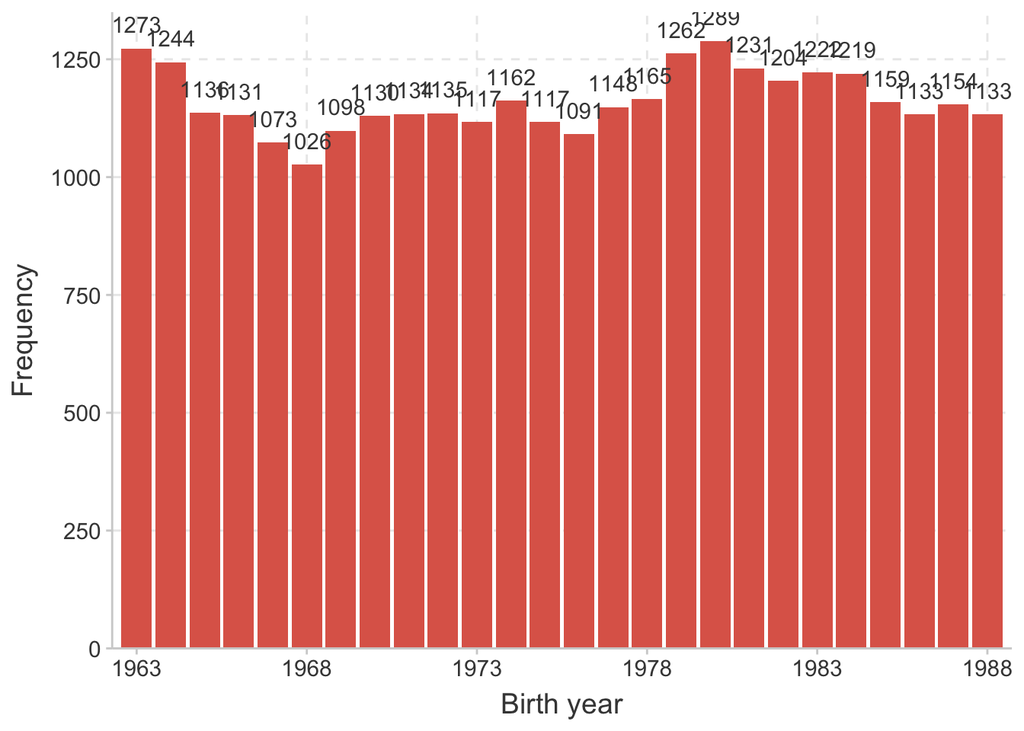

```r
child_sample %>%
  count(birth_year) |>
  ggplot(aes(x = birth_year, y = n)) +
  geom_col() +
  geom_text(aes(label = n), vjust = -1) +
  labs(x = "Birth year", y = "Frequency") +
  scale_x_continuous(breaks = seq(1963, 1988, 5), expand = c(0.01,0.01)) +
  scale_y_continuous(lim = c(0, 1350), breaks = seq(0, 1250, 250), expand = c(0,0))
```

### Restriction (ii): observed as child (i.e., with parents) at least once

- should we restrict to some age at which individual is observed as child, perhaps less than 17? $\rightarrow$ 89.6% are first observed as child at age 17 or less (42% are first observed at age 0 or 1), so probably not that important

```r
# keep only individuals who were observed at least once as children
# identify children
ind_2019_child <- ind_2019_clean %>%
  select(ind_id_68, all_of(rel_head_vars))  %>%
  pivot_longer(cols = -ind_id_68,
               names_to = "relation_to_head_var",
               values_to = "relation_to_head") %>%
  mutate(year = rep(years, n()/length(years)))
setDT(ind_2019_child)
ind_2019_child[relation_to_head != 0] %>% count(substr(relation_to_head,1,1), sort = T) %>% count_to_pct()
```

| substr(relation_to_head, 1, 1) | n | pct |
| --- | --- | --- |
| 3 | 362124 | 0.400225907 |
| 1 | 308213 | 0.340642507 |
| 2 | 173967 | 0.192271433 |
| 6 | 23195 | 0.025635528 |
| 8 | 9084 | 0.010039799 |
| 7 | 9058 | 0.010011063 |
| 4 | 7569 | 0.008365394 |
| 5 | 7233 | 0.007994041 |
| 9 | 4356 | 0.004814329 |

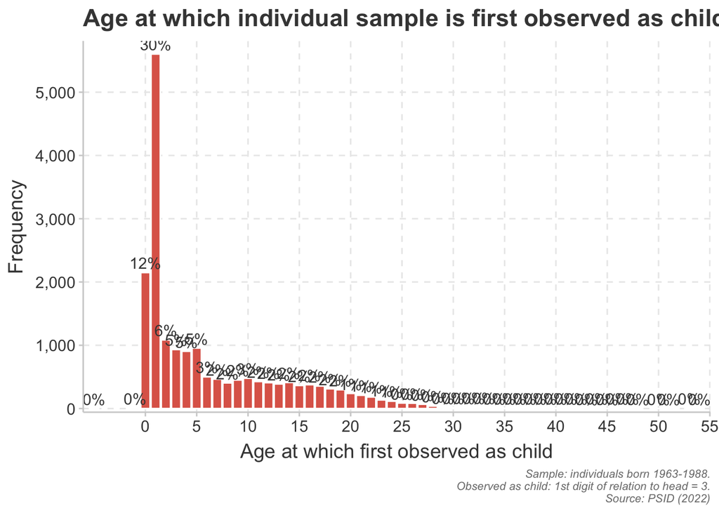

```r
# children: 1-digit relation to head == 3
# and obtain age at which first observed as child
ind_2019_child <- ind_2019_child %>%
  filter(substr(relation_to_head, 1, 1) == 3) %>%
  left_join(child_sample %>% select(ind_id_68, birth_year)) %>%
  mutate(age = year - birth_year) %>%
  group_by(ind_id_68) %>%
  slice_min(order_by = age) %>%
  ungroup

# plot distribution of age at which child is first observed as child
ind_2019_child %>%
  group_by(age) %>%
  summarise(n_obs = n()) %>%
  mutate(pct = n_obs/sum(n_obs)) %>%
  ggplot(aes(x = age, y = n_obs)) +
  geom_col(color = "white") +
  geom_text(aes(y = n_obs + 150, label = paste0(round(pct*100,0), "%"))) +
  scale_x_continuous(breaks = seq(0,100,5), expand = c(0.01, 0.01)) +
  scale_y_continuous(expand = c(0.01, 0.01), labels = scales::comma) +
  labs(x = "Age at which first observed as child",
       y = "Frequency",
       caption = paste0("Sample: individuals born ", birth_year_min, "-", birth_year_max, ".
       Observed as child: 1st digit of relation to head = 3.
       Source: PSID (2022)"),
       title = "Age at which individual sample is first observed as child")
```

```r
ind_2019_child |> count(age <= 17) |> count_to_pct()
```

| age <= 17 | n | pct |
| --- | --- | --- |
| FALSE | 1937 | 0.1040726 |
| TRUE | 16675 | 0.8959274 |

```r
# n obs.: 18,612
child_sample <- child_sample %>%
  filter(ind_id_68 %in% ind_2019_child$ind_id_68)
child_sample %>% count()
```

| n |
| --- |
| 18612 |

```r
child_sample %>% count(birth_year)
```

| birth_year | n |
| --- | --- |
| 1963 | 633 |
| 1964 | 589 |
| 1965 | 555 |
| 1966 | 584 |
| 1967 | 562 |
| 1968 | 517 |
| 1969 | 575 |
| 1970 | 628 |
| 1971 | 666 |
| 1972 | 674 |

[output cut: 16 more lines]

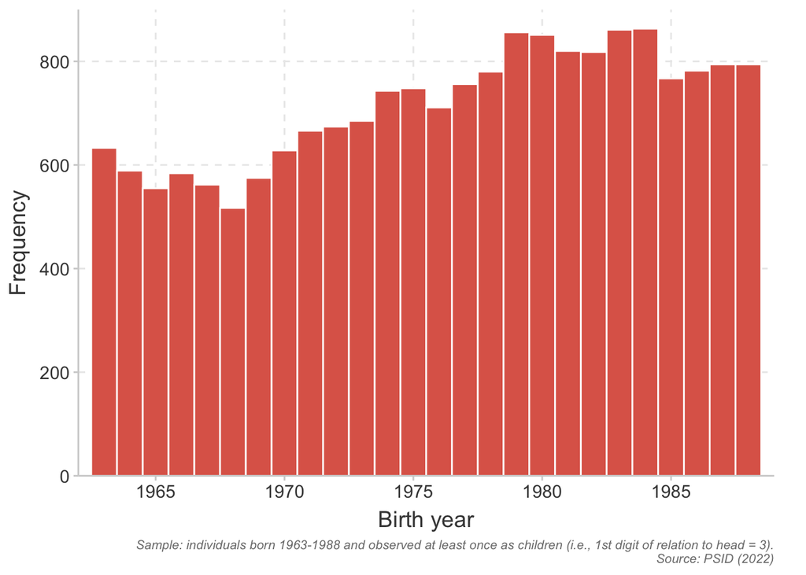

```r
rm(ind_2019_child)

# plot distribution of birth years
child_sample %>%
  ggplot(aes(x = birth_year)) +
  geom_histogram(binwidth = 1, color = "white") +
  scale_x_continuous(lim = c(1962, 1989), breaks = seq(1960, 1995, 5), expand = c(0,0)) +
  scale_y_continuous(lim = c(0, 900), breaks = seq(0, 900, 200), expand = c(0,0)) +
  labs(x = "Birth year",
       y = "Frequency",
       caption = "Sample: individuals born 1963-1988 and observed at least once as children (i.e., 1st digit of relation to head = 3).
       Source: PSID (2022)") +
  theme(plot.margin = unit(c(6,20,6,6), "points"))
```

### Restriction (iii): observed at least once as reference person or spouse/partner between 30 and 50

$\rightarrow$ so their incomes in adulthood can be measured

NB: “Individuals moving in or born subsequent to the [YEAR] interview received the [YEAR] ID number of the family into which they moved.”

```r
age_min = 30
age_max = 50

# family interview number
psid_vars %>% filter(var_id == 419) %>% count(text)
```

| text | n |
| --- | --- |
| 01>SURVEY INFORMATION:\r\n02>Interview Information\r\n03>id (interview) number: | 41 |

```r
itw_num_vars <- psid_vars %>% filter(var_id == 419) %>% pull(variable)
used_vars <- bind_cols(used_vars, itw_num_vars = itw_num_vars)

# sequence number
seq_num_vars <- psid_vars %>% filter(var_id == "426") %>% pull(variable)
used_vars <- bind_cols(used_vars, seq_num_vars = seq_num_vars)
seq_num_vars <- seq_num_vars[!is.na(seq_num_vars)]

# obtain family interview number and position relative to head
child_sample_long <- ind_2019_clean %>%
  filter(ind_id_68 %in% child_sample$ind_id_68) %>%
  select(ind_id_68, birth_year, gender, all_of(c(itw_num_vars, rel_head_vars, seq_num_vars))) %>%
  rename_with(~ map2_chr(itw_num_vars, years, ~ paste0(.x, "_itw_", .y)), all_of(itw_num_vars)) %>%
  rename_with(~ map2_chr(rel_head_vars, years, ~ paste0(.x, "_rel_", .y)), all_of(rel_head_vars)) %>%
  rename_with(~ map2_chr(seq_num_vars, years[years != 1968], ~ paste0(.x, "_seq_", .y)), all_of(seq_num_vars)) %>%
  pivot_longer(cols = -c(ind_id_68, birth_year, gender),
               names_to = c(".value", "year"),
               names_pattern = ".(itw|rel|seq)_(\\d+)") %>%
  rename(itw_num = itw,
         rel_head = rel,
         seq_num = seq) %>%
  mutate(year = as.numeric(year),
         age = year - birth_year)
child_sample_long %>% head
```

| ind_id_68 | birth_year | gender | year | itw_num | rel_head | seq_num | age |
| --- | --- | --- | --- | --- | --- | --- | --- |
| 1030 | 1972 | Female | 1968 | 1 | 0 | NA | -4 |
| 1030 | 1972 | Female | 1969 | 1964 | 0 | 0 | -3 |
| 1030 | 1972 | Female | 1970 | 837 | 0 | 0 | -2 |
| 1030 | 1972 | Female | 1971 | 109 | 0 | 0 | -1 |
| 1030 | 1972 | Female | 1972 | 494 | 0 | 0 | 0 |
| 1030 | 1972 | Female | 1973 | 17 | 3 | 3 | 1 |

```r
# head or spouse between ages 30-50
ind_2019_child <- child_sample_long %>%
  filter(age %in% age_min:age_max & substr(rel_head, 1, 1) %in% 1:2) %>%
  pull(ind_id_68) %>% unique()

# identify individuals in child sample observed at least once as head or spouse between ages 30-50
# only 30.4%
child_sample %>% count(ind_id_68 %in% ind_2019_child) %>% count_to_pct()
```

| ind_id_68 %in% ind_2019_child | n | pct |
| --- | --- | --- |
| FALSE | 12957 | 0.6961638 |
| TRUE | 5655 | 0.3038362 |

```r
setDT(child_sample)
child_sample[, obs_head_spouse := (ind_id_68 %in% ind_2019_child)]
child_sample[obs_head_spouse == F] %>% count(itw_num_cat, sort = T) %>% count_to_pct()
```

| itw_num_cat | n | pct |
| --- | --- | --- |
| Member of, or moved into, a family from the 1968 Census sample | 5871 | 0.45311414679 |
| Member of, or moved into, a family from the Latino sample added in 1990 | 3133 | 0.24179979934 |
| Member of, or moved into, a family from the 1968 SRC cross-section sample | 3121 | 0.24087365903 |
| Member of, or moved into, a family from the Latino sample added in 1992 | 465 | 0.03588793702 |
| Member of, or moved into, a family from the Immigrant sample added in 1997 | 294 | 0.02269043760 |
| Member of, or moved into, a family from the Immigrant sample added in 1999 | 56 | 0.00432198811 |
| Member of, or moved into, a family from the Immigrant sample added in 2017 | 16 | 0.00123485375 |
| Multiplicity sample not interviewed until 2019 | 1 | 0.00007717836 |

```r
child_sample[obs_head_spouse == F] %>% count(person_num_cat, sort = T) %>% count_to_pct()
```

| person_num_cat | n | pct |
| --- | --- | --- |
| 1. Individuals living in core sample families at the time of the 1968 interview; individuals living in Latino sample families at the time of the 1990 (or 1992) interview; individuals living in Immigra… | 4769 | 0.3680635950 |
| 3. Individuals born into the core sample since the 1968 interview, the Latino sample since the 1990 (or 1992) interview, or the Immigrant sample since the 1997 (or 1999) or 2017 (or 2019) interview an… | 4537 | 0.3501582156 |
| 4. Individuals who moved into a core family for the first time after the 1968 interview or who have no sample parent; individuals from the Latino sample, other than the spouse of a 1990 (or 1992) Head… | 3568 | 0.2753723856 |
| 2. Children or stepchildren of a 1968 core sample Head who were under 25 and living in institutions at the time of the 1968 interview; children of a Latino sample 1990 (or 1992) Head who were under 25… | 75 | 0.0057883769 |
| 7. Individuals who moved into a core family for the first time after the 1968 interview or who have no sample parent; individuals from the Latino sample, other than the spouse of a 1990 (or 1992) Head… | 8 | 0.0006174269 |

```r
child_sample[obs_head_spouse == F] %>% count(sample_status, sort = T) %>% count_to_pct() # 37% of missing are original sample
```

| sample_status | n | pct |
| --- | --- | --- |
| This individual is original sample | 4844 | 0.373851972 |
| This individual is born-in sample | 4537 | 0.350158216 |
| This individual is nonsample and not part of the elderly group | 2973 | 0.229451262 |
| This individual is moved-in sample | 574 | 0.044300378 |
| This individual was a followable nonsample parent | 29 | 0.002238172 |

```r
child_sample[obs_head_spouse == F] %>% count(ER32008, sort = T) %>% count_to_pct()
```

| ER32008 | n | pct |
| --- | --- | --- |
| 1 | 1507 | 0.116307787 |
| 1997 | 1442 | 0.111291194 |
| 1993 | 908 | 0.070077950 |
| 1994 | 680 | 0.052481284 |
| 1992 | 641 | 0.049471328 |
| 1995 | 633 | 0.048853901 |
| 1991 | 489 | 0.037740218 |
| 1990 | 431 | 0.033263873 |
| 1987 | 322 | 0.024851432 |
| 1989 | 310 | 0.023925291 |

[output cut: 35 more lines]

```r
# at what age was the individual's first non response (among individuals who were not never nonresponse)
# 89% prior to age 25
child_sample[obs_head_spouse == F & !ER32008 %in% 0:4] %>% count((ER32008 - birth_year) < 25) %>% count_to_pct()
```

| (ER32008 - birth_year) < 25 | n | pct |
| --- | --- | --- |
| FALSE | 1167 | 0.1057065 |
| TRUE | 9873 | 0.8942935 |

```r
# merge taxable income to long df
child_sample_long <- child_sample_long %>%
  left_join(inc_all, by = c("year" = "year_psid", "itw_num"))

# obtain sample/non-sample status
child_sample_long <- child_sample_long %>%
  left_join(ind_2019_clean %>% select(ind_id_68, sample_status))
child_sample_long %>%
  filter(age %in% age_min:age_max) %>%
  group_by(ind_id_68, sample_status) %>%
  summarise(n_head_spouse = sum(substr(rel_head, 1, 1) %in% 1:2)) %>%
  ungroup() %>%
  filter(n_head_spouse == 0) %>%
  count(sample_status, sort = T) %>% count_to_pct()
```

| sample_status | n | pct |
| --- | --- | --- |
| This individual is original sample | 4844 | 0.373851972 |
| This individual is born-in sample | 4537 | 0.350158216 |
| This individual is nonsample and not part of the elderly group | 2973 | 0.229451262 |
| This individual is moved-in sample | 574 | 0.044300378 |
| This individual was a followable nonsample parent | 29 | 0.002238172 |

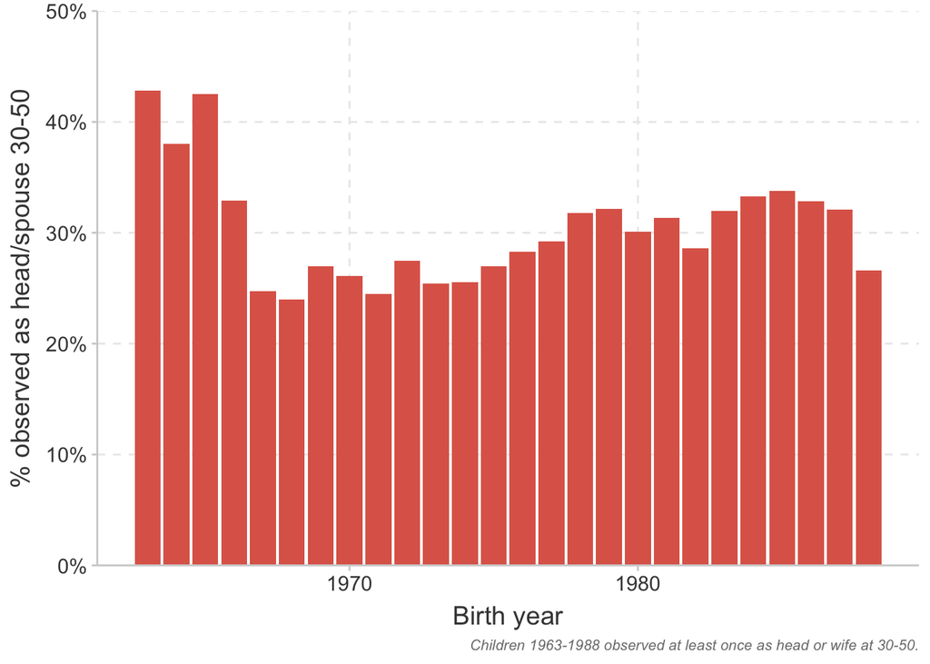

```r
# plot % by birth year
child_sample %>%
  group_by(ind_id_68, birth_year, gender) %>%
  group_by(birth_year) %>%
  summarise(inc_obs_pct = mean(obs_head_spouse)) %>%
  ggplot(aes(x = birth_year, y = inc_obs_pct)) +
  geom_col() +
  labs(x = "Birth year",
       y = paste0("% observed as head/spouse ", age_min, "-", age_max),
       caption = paste0("Children ", birth_year_min, "-", birth_year_max, " observed at least once as head or wife at ", age_min, "-", age_max, ".")) +
  scale_y_continuous(lim = c(0,.5), labels = scales::percent, expand = c(0, 0))
```

```r
# keep only children observed as head or spouse at ages 30-50
child_sample <- child_sample[obs_head_spouse == T]
child_sample %>% count()
```

| n |
| --- |
| 5655 |

### Cleaned child data.frame

```r
# create dataframe with only cleaned variables
child_sample_clean <- child_sample %>%
  select(ind_id_68, gender, birth_year, itw_num_cat, person_num_cat, sample_status)
child_sample_clean %>% count(sample_status, sort = T) %>% count_to_pct()
```

| sample_status | n | pct |
| --- | --- | --- |
| This individual is born-in sample | 3743 | 0.661892131 |
| This individual is original sample | 1349 | 0.238549956 |
| This individual is moved-in sample | 449 | 0.079398762 |
| This individual is nonsample and not part of the elderly group | 55 | 0.009725906 |
| This individual was a followable nonsample parent | 53 | 0.009372237 |
| This individual is joint inclusion sample | 6 | 0.001061008 |

### Identify parents

Follow Chetty et al. (2014 QJE): *parents are first family unit in which child is observed, then follow parents’ family taxable income.*

Note that this differs from:  
$\rightarrow$ Mazumder (2016), who uses the PSID’s Family Identification Mapping System (FIMS) to identify fathers.  
$\rightarrow$ Lee and Solon (2009) use the family taxable income in which the children find themselves between ages 15 and 17. This may potentially be overly restrictive in case some children are observed only prior to age 15.

Alternative way to define parents: heads and spouses in which child is observed $\rightarrow$ problem this prevents identifying parent income once the child becomes a head of household.

(As a robustness, we could identify parents observed with children at a given age.)

```r
# identify family id in which child is first observed
setDT(child_sample_long)
child_first_fam <- child_sample_long[ind_id_68 %in% child_sample_clean$ind_id_68] %>%
  select(ind_id_68, birth_year, gender, year, itw_num, rel_head, age) %>%
  filter(substr(rel_head, 1, 1) == 3) %>%
  group_by(ind_id_68) %>%
  slice_min(order_by = year) %>%
  ungroup()
setDT(child_first_fam)
child_first_fam[, .N, by = ind_id_68] %>% count(N)
```

| N | n |
| --- | --- |
| 1 | 5655 |

```r
# I add a variable in seq_num_vars because sequence number does not exist for 1968 by definition, and this prevents me from using the simple code below. I'll then recode values for 1968 sequence number.
seq_num_vars <- c("ER30000", seq_num_vars)

# obtain first family reference head and spouse identifiers
child_first_parents <- child_first_fam %>%
  select(child_fam = ind_id_68, birth_year, gender, year, itw_num, age) %>%
  left_join(var_reshape_fct(ind_2019,
                            set_var_names = list(itw_num_vars, rel_head_vars, seq_num_vars),
                            names_to_new = c("itw_num_vars", "rel_head_vars", "seq_num_vars"),
                            values_to_new = c("itw_num", "rel_to_head", "seq_num")) %>%
              select(ind_id_68, year, itw_num, rel_to_head, seq_num) %>%
              mutate(seq_num = ifelse(year == 1968, NA, seq_num)), by = c("itw_num", "year")) %>%
  filter(substr(rel_to_head, 1, 1) %in% 1:2) %>%
  select(ind_id_68, year, rel_to_head, seq_num, gender, child_fam) %>%
  arrange(child_fam)
setDT(child_first_parents)

# <2% have 2 heads
# this is because the relation to head variable is relative to the head in year t-1
# therefore some former heads may have moved out of the FU
child_first_parents %>%
  group_by(child_fam) %>%
  summarise(n_head = sum(substr(rel_to_head, 1, 1) == 1)) %>%
  ungroup() %>% count(n_head) %>% count_to_pct()
```

| n_head | n | pct |
| --- | --- | --- |
| 1 | 5556 | 0.98249337 |
| 2 | 99 | 0.01750663 |

```r
child_first_parents <- child_first_parents %>%
  group_by(child_fam) %>%
  mutate(n_head = sum(substr(rel_to_head, 1, 1) == 1)) %>%
  ungroup()

child_first_parents %>% filter(n_head > 1) %>% count(seq_num)
```

| seq_num | n |
| --- | --- |
| 1 | 99 |
| 2 | 13 |
| 51 | 15 |
| 71 | 52 |
| 72 | 3 |
| 75 | 1 |
| 81 | 31 |
| 82 | 3 |

```r
child_first_parents %>% filter(n_head > 1) %>% count(year, sort = T)
```

| year | n |
| --- | --- |
| 1994 | 18 |
| 1983 | 16 |
| 1992 | 16 |
| 1997 | 15 |
| 1988 | 14 |
| 1972 | 11 |
| 1977 | 11 |
| 1981 | 10 |
| 2003 | 9 |
| 1975 | 8 |

[output cut: 21 more lines]

```r
# keep only parents that were in the family at the time of the interview
# i.e., 1-digit of sequence number = 1:2
# or who are observed in 1968 (who by definition are in the family unit)
child_first_parents <- child_first_parents %>%
  filter(year == 1968 | substr(seq_num, 1, 1) %in% 1:2)
child_first_parents %>% summarise(n_distinct(child_fam))
```

| n_distinct(child_fam) |
| --- |
| 5655 |

```r
# all children have well identified parents!
child_first_parents %>%
  group_by(child_fam) %>%
  summarise(n_head = sum(substr(rel_to_head, 1, 1) == 1)) %>% count(n_head)
```

| n_head | n |
| --- | --- |
| 1 | 5655 |

```r
# 20% of children are observed with only one parent
child_first_parents %>%
  group_by(child_fam) %>%
  summarise(n_parents = n()) %>% ungroup() %>%
  count(n_parents) %>% count_to_pct()
```

| n_parents | n | pct |
| --- | --- | --- |
| 1 | 1142 | 0.2019452 |
| 2 | 4513 | 0.7980548 |

```r
# create long dataframe of parents'
parents_sample <- ind_2019_clean[ind_id_68 %in% child_first_parents$ind_id_68]
parents_sample_long <- parents_sample %>%
  select(ind_id_68, birth_year, gender, all_of(c(itw_num_vars, rel_head_vars))) %>%
  rename_with(~ map2_chr(itw_num_vars, years, ~ paste0(.x, "_itw_", .y)), all_of(itw_num_vars)) %>%
  rename_with(~ map2_chr(rel_head_vars, years, ~ paste0(.x, "_rel_", .y)), all_of(rel_head_vars)) %>%
  pivot_longer(cols = -c(ind_id_68, gender, birth_year),
               names_to = c(".value", "year"),
               names_pattern = ".(itw|rel)_(\\d+)") %>%
  rename(itw_num = itw,
         rel_head = rel) %>%
  mutate(year = as.numeric(year),
         age = year - birth_year)
setDT(parents_sample_long)

# now that I have the parents' identifier, obtain their incomes when they are reference or spouse
parents_sample_long <- parents_sample_long %>%
  left_join(inc_all, by = c("year" = "year_psid", "itw_num"))

# clean parents data.frame
parents_sample_clean <- parents_sample %>%
  select(ind_id_68, birth_year, gender, itw_num_cat, person_num_cat, sample_status)
```

## Display and export used variables

```r
used_vars
```

| value | fam_id_vars | rel_head_vars | age_vars | birth_year_vars | itw_num_vars | seq_num_vars |
| --- | --- | --- | --- | --- | --- | --- |
| 1968 | V3 | ER30003 | ER30004 | NA | ER30001 | NA |
| 1969 | V442 | ER30022 | ER30023 | NA | ER30020 | ER30021 |
| 1970 | V1102 | ER30045 | ER30046 | NA | ER30043 | ER30044 |
| 1971 | V1802 | ER30069 | ER30070 | NA | ER30067 | ER30068 |
| 1972 | V2402 | ER30093 | ER30094 | NA | ER30091 | ER30092 |
| 1973 | V3002 | ER30119 | ER30120 | NA | ER30117 | ER30118 |
| 1974 | V3402 | ER30140 | ER30141 | NA | ER30138 | ER30139 |
| 1975 | V3802 | ER30162 | ER30163 | NA | ER30160 | ER30161 |
| 1976 | V4302 | ER30190 | ER30191 | NA | ER30188 | ER30189 |
| 1977 | V5202 | ER30219 | ER30220 | NA | ER30217 | ER30218 |

[output cut: 31 more lines]

```r
fwrite(used_vars, here("data/used_vars_sample.csv"))
```

## Export intermediate datasets

```r
fwrite(child_first_parents, here("data/child_first_parents.csv"))
fwrite(parents_sample, here("data/parents_sample.csv"))
fwrite(parents_sample_clean, here("data/parents_sample_clean.csv"))
fwrite(parents_sample_long, here("data/parents_sample_long.csv"))
fwrite(child_sample, here("data/child_sample.csv"))
fwrite(child_sample_clean, here("data/child_sample_clean.csv"))
fwrite(child_sample_long, here("data/child_sample_long.csv"))
```